# Data exploration with RMarkdown and ggplot2 (dPrep)

Last updated: 30 January 2026

# Getting Started

In this tutorial, you’ll explore a data set and learn how to understand the context in which it was collected. By the end, you'll be able to generate plots with `ggplot2`, and create an **RMarkdown document** rendered as a **PDF or HTML file**--perfect for sharing insights or starting discussions!

## Data

This tutorial makes use of the [Google’s COVID-19 Community Mobility Reports](https://www.google.com/covid19/mobility/), a data set that helped governments and researchers understand how the pandemic affected daily life and the economy. The data shows *daily percentage changes* in visits to different places, compared to the same day of the week before COVID-19 (January 3 – February 6, 2020).

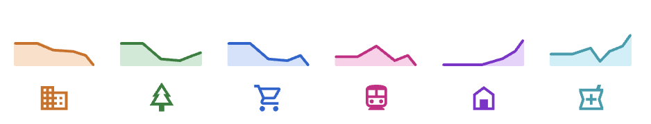

The data includes six place categories:

- **Retail & recreation** (e.g., malls, restaurants)
- **Grocery & pharmacy** (e.g., supermarkets, drugstores)
- **Parks**
- **Transit stations** (e.g., bus and train stations)
- **Workplaces**
- **Residences**

We will work with the **Dutch part** of the data (tagged with `NL`).

# Part 1: Loading and Inspecting the Data

## Let's Create a New R Project

1. Create a new R project:
   - File → New Project → New Directory → New Project
   - Name it *data_exploration*
   - Choose a location and click Create
2. Add a `raw_data` folder:
   - Option 1 (Code): Run `dir.create("raw_data")`
   - Option 2 (Manual): Click *New Folder (📁)* in the Files pane

## Downloading and Loading the Data Set

1. Download the [**Region CSVs archive**](https://www.google.com/covid19/mobility/) from Google.
2. Unzip the file--it contains many country-specific datasets.
3. Move `2020_NL_Region_Mobility_Report.csv` into your `raw_data` folder.
4. Create a *new R script* in your project folder.

Now, load the data into R using `dplyr`'s `read_csv` function:

```r
library(dplyr)
mobility <- read_csv("raw_data/2020_NL_Region_Mobility_Report.csv")
```

**Troubleshooting**

- If R doesn’t find your file: Click **Session → Set working directory → To source file location**.
- Avoid using `setwd()` — hardcoding directories can cause problems!
- Don't manage to download the file directly from Google? You can also use an archived version on this course's GitHub's repository; just run the code below in RStudio:

```r
library(dplyr)
mobility <- read_csv('https://github.com/hannesdatta/course-dprep/raw/main/material/tutorials/r-markdown/2020_NL_Region_Mobility_Report.csv')
```

## Exercise 1: Data Inspection

Examine the `mobility` data frame and describe its *structure* in your own words. Consider the following:

- What are the column names?
- How are the variables/metrics defined?
- What is the unit of analysis (i.e., what uniquely identifies each row in the dataset)?
- Is the data sorted in any specific way?
- Are all values in each column complete and meaningful?
- Are text-based data ("strings") properly encoded, or do they contain unusual characters that make them hard to read?

**Tips:**

- Take a **look** at the data using the function `head(mobility)`, or `View(mobility)`. If you'd like to view more rows with `head`, use `head(mobility, 100)` (for, e.g., the first 100 rows). (`tail()` gives you the last rows of the data).
- The command `summary(mobility)` generates descriptive statistics for all variables in the data. You can also use this command on individual columns (e.g., `summary(mobility$retail_and_recreation_percent_change_from_baseline)`).
- Character or factor columns are best inspected using the `table()` command. These will create frequency tables.

```r
head(mobility)
```

```
## # A tibble: 6 × 15
##   country_region_code country_region sub_region_1 sub_region_2 metro_area
##   <chr>               <chr>          <chr>        <chr>        <lgl>
## 1 NL                  Netherlands    <NA>         <NA>         NA
## 2 NL                  Netherlands    <NA>         <NA>         NA
## 3 NL                  Netherlands    <NA>         <NA>         NA
## 4 NL                  Netherlands    <NA>         <NA>         NA
## 5 NL                  Netherlands    <NA>         <NA>         NA
## 6 NL                  Netherlands    <NA>         <NA>         NA
## # ℹ 10 more variables: iso_3166_2_code <chr>, census_fips_code <lgl>,
## #   place_id <chr>, date <date>,
## #   retail_and_recreation_percent_change_from_baseline <dbl>,
## #   grocery_and_pharmacy_percent_change_from_baseline <dbl>,
## #   parks_percent_change_from_baseline <dbl>,
## #   transit_stations_percent_change_from_baseline <dbl>,
## #   workplaces_percent_change_from_baseline <dbl>, …
```

```r
summary(mobility)
```

```
##  country_region_code country_region     sub_region_1       sub_region_2
##  Length:110241       Length:110241      Length:110241      Length:110241
##  Class :character    Class :character   Class :character   Class :character
##  Mode  :character    Mode  :character   Mode  :character   Mode  :character
##
##
##
##
##  metro_area     iso_3166_2_code    census_fips_code   place_id
##  Mode:logical   Length:110241      Mode:logical     Length:110241
##  NA's:110241    Class :character   NA's:110241      Class :character
##                 Mode  :character                    Mode  :character
##
##
##
##
##       date            retail_and_recreation_percent_change_from_baseline
##  Min.   :2020-02-15   Min.   :-97.00
##  1st Qu.:2020-05-04   1st Qu.:-30.00
##  Median :2020-07-21   Median :-15.00
##  Mean   :2020-07-24   Mean   :-14.86
##  3rd Qu.:2020-10-17   3rd Qu.: -1.00
##  Max.   :2020-12-31   Max.   :199.00
##                       NA's   :47051
##  grocery_and_pharmacy_percent_change_from_baseline
##  Min.   :-96.000
##  1st Qu.: -8.000
##  Median : -2.000
##  Mean   : -1.325
##  3rd Qu.:  5.000
##  Max.   :222.000
##  NA's   :39935
##  parks_percent_change_from_baseline
##  Min.   :-88.00
##  1st Qu.:-10.00
##  Median : 16.00
##  Mean   : 31.53
##  3rd Qu.: 56.00
##  Max.   :728.00
##  NA's   :87811
```

[output cut: 9 more lines]

```
##  Min.   :-90.00
##  1st Qu.:-41.00
##  Median :-28.00
##  Mean   :-27.31
##  3rd Qu.:-16.00
##  Max.   : 66.00
##  NA's   :6893
##  residential_percent_change_from_baseline
##  Min.   :-4.000
##  1st Qu.: 6.000
##  Median : 8.000
##  Mean   : 8.839
##  3rd Qu.:12.000
##  Max.   :32.000
##  NA's   :48247
```

```r
table(mobility$sub_region_1)
```

```
##
##       Drenthe     Flevoland     Friesland    Gelderland     Groningen
##          3922          2127          5303         15372          4701
##       Limburg North Brabant North Holland    Overijssel South Holland
##          9134         18029         14189          7573         18115
##       Utrecht       Zeeland
##          7495          3960
```

```r
# The dataset shows the mobility changes at a national, regional, and city level in the Netherlands, for multiple categories of places. The records are sorted by date, and are grouped by location (starting with country stats).

# Moreover, three of the columns (`metro_area`, `iso_3166_2_code`, `census_flips_code`) contain only empty data, and two other columns (`sub_region_1`, `sub_region_2`) are blank for a subset of the values. This also holds for the columns related to percentage changes in mobility scores which are missing in some cases (especially on a city-level).
```

## Exercise 2: Filtering

Please create a new dataset, called `filtered_df`. Set the filter such that you only retain observations for The Netherlands as a whole (and not province-level data).

**Tips:**

- Make use of the `tidyverse` verbs (remember from the R Bootcamp) `filter`, and the piping character `%>%`
- In your filter, choose observations where `sub_region_1` is NA (`is.na(sub_region_1)`) and `sub_region_2` is NA (`is.na(sub_region_2`))
- Example: `filtered_df = mobility %>% <CONTINUE HERE>`

```r
# hint: when sub_region_1 and sub_region_2 are NA,
# the data pertains to the whole of The Netherlands.
filtered_df <- mobility %>% filter(is.na(sub_region_1) & is.na(sub_region_2))
summary(filtered_df)
```

```
##  country_region_code country_region     sub_region_1       sub_region_2
##  Length:321          Length:321         Length:321         Length:321
##  Class :character    Class :character   Class :character   Class :character
##  Mode  :character    Mode  :character   Mode  :character   Mode  :character
##
##
##
##  metro_area     iso_3166_2_code    census_fips_code   place_id
##  Mode:logical   Length:321         Mode:logical     Length:321
##  NA's:321       Class :character   NA's:321         Class :character
##                 Mode  :character                    Mode  :character
##
##
##
##       date            retail_and_recreation_percent_change_from_baseline
##  Min.   :2020-02-15   Min.   :-83.0
##  1st Qu.:2020-05-05   1st Qu.:-34.0
##  Median :2020-07-24   Median :-19.0
##  Mean   :2020-07-24   Mean   :-19.5
##  3rd Qu.:2020-10-12   3rd Qu.: -3.0
##  Max.   :2020-12-31   Max.   : 21.0
##  grocery_and_pharmacy_percent_change_from_baseline
##  Min.   :-75.000
##  1st Qu.: -7.000
##  Median : -4.000
##  Mean   : -4.153
##  3rd Qu.:  0.000
##  Max.   : 24.000
##  parks_percent_change_from_baseline
##  Min.   :-59.0
##  1st Qu.: 11.0
##  Median : 43.0
##  Mean   : 66.2
##  3rd Qu.:107.0
##  Max.   :286.0
##  transit_stations_percent_change_from_baseline
##  Min.   :-75.00
##  1st Qu.:-50.00
##  Median :-44.00
##  Mean   :-41.33
##  3rd Qu.:-36.00
##  Max.   : 10.00
##  workplaces_percent_change_from_baseline
##  Min.   :-85.00
##  1st Qu.:-39.00
##  Median :-29.00
##  Mean   :-26.04
##  3rd Qu.: -7.00
##  Max.   : 24.00
##  residential_percent_change_from_baseline
##  Min.   :-1.000
##  1st Qu.: 5.000
##  Median : 8.000
##  Mean   : 8.548
##  3rd Qu.:11.000
##  Max.   :27.000
```

```r
# The number of missing values on most variables has drastically decreased. That's good news! It seems like the data is most "complete" at the national level.
```

## Exercise 3: Summary statistics

Let's now start zooming in on some of the metrics in the filtered data set to check what they really mean. Haven't solved Exercise 2? Make sure to run the code provided in the solutions to exercise 2 before continuing.

The dataset reports percentage changes in visits compared to a **baseline** (median values from January 3 – February 6, 2020).

Are percentages expressed as **0 to 1** (e.g., `0.50` means +50%) or **0 to 100** (e.g., `50` means +50%)? Use `summary()` to check the range of values. What do you conclude?

```r
# Exploring the range
summary(mobility$retail_and_recreation_percent_change_from_baseline)
```

```
##    Min. 1st Qu.  Median    Mean 3rd Qu.    Max.    NA's
##  -97.00  -30.00  -15.00  -14.86   -1.00  199.00   47051
```

```r
# --> the range seems to be measured on a scale on which 100 means 100%. As the reported stats indicate percentage-change relative to a baseline, the observed values are also valid (i.e., mobility can decrease by -97%, and increase by 199%).
```

## Exercise 4: Generating a table with descriptive statistics

It can be quite handy to include a good-looking summary table with descriptive statistics in a Markdown-based report. For this, you can first make use of the `describe` function from the `psych` package (install it first if you don't have it, using `install.packages('psych')`. Then, you can "pipe" it through `knitr`'s `kable` function to render it nicely in your document.

We'll show you a starting code snippet here that you can extend. Run it in RStudio and see what it does!

```r
# generate table
summary_table = psych::describe(
  filtered_df %>% select(retail_and_recreation_percent_change_from_baseline),
  skew= F
  )

# output in rmarkdown document
summary_table %>% knitr::kable()
```

|  | vars | n | mean | sd | median | min | max | range | se |
| --- | --- | --- | --- | --- | --- | --- | --- | --- | --- |
| retail_and_recreation_percent_change_from_baseline | 1 | 321 | -19.49844 | 19.10287 | -19 | -83 | 21 | 104 | 1.066218 |

Now, please extend the code snippet so that it shows the descriptive statistics of all "change_from_baseline" variables in the data.

**Tip**:

- run `colnames(filtered_df)` to see which column names are available
- insert them manually in the code snippet shown above.
- set the arguments `digits` in the `kable()` function to `digits = 2` (so that the table rounds off all numbers to 2 digits - making the table look more compact)

```r
summary_table = psych::describe(
  filtered_df %>% select(retail_and_recreation_percent_change_from_baseline,
                         grocery_and_pharmacy_percent_change_from_baseline,
                         parks_percent_change_from_baseline,
                         transit_stations_percent_change_from_baseline,
                         workplaces_percent_change_from_baseline,
                         residential_percent_change_from_baseline),
  skew= F
  )

# as an alternative to filtered_df %>% select(...), you could also use
# filtered_df %>% select(ends_with('from_baseline')) - saving you the
# time to manually type variable names.

# output in rmarkdown document
summary_table %>% knitr::kable(digits = 2)
```

|  | vars | n | mean | sd | median | min | max | range | se |
| --- | --- | --- | --- | --- | --- | --- | --- | --- | --- |
| retail_and_recreation_percent_change_from_baseline | 1 | 321 | -19.50 | 19.10 | -19 | -83 | 21 | 104 | 1.07 |
| grocery_and_pharmacy_percent_change_from_baseline | 2 | 321 | -4.15 | 9.30 | -4 | -75 | 24 | 99 | 0.52 |
| parks_percent_change_from_baseline | 3 | 321 | 66.20 | 72.74 | 43 | -59 | 286 | 345 | 4.06 |
| transit_stations_percent_change_from_baseline | 4 | 321 | -41.33 | 15.89 | -44 | -75 | 10 | 85 | 0.89 |
| workplaces_percent_change_from_baseline | 5 | 321 | -26.04 | 19.83 | -29 | -85 | 24 | 109 | 1.11 |
| residential_percent_change_from_baseline | 6 | 321 | 8.55 | 5.47 | 8 | -1 | 27 | 28 | 0.31 |

# Part 2: Data Cleaning & Transformation

When working with a new dataset, you often need to filter and clean it. For example, raw data can contain:

- Columns that are irrelevant or unnecessary for our analysis
- Subsets of data that we don’t need or want to filter out

In case you haven't fully completed part 1 of this tutorial, please run this code snippet which ensures that all of the packages and data sets are loaded that you will need to use.

```r
library(dplyr)
library(psych)
library(tidyverse)

mobility <- read_csv('https://github.com/hannesdatta/course-dprep/raw/main/material/tutorials/r-markdown/2020_NL_Region_Mobility_Report.csv')
filtered_df <- mobility %>% filter(is.na(sub_region_1) & is.na(sub_region_2))
```

## Exercise 5: Dropping columns

To make the dataset easier to work with, we can select only the columns we need using `dplyr`'s `select()` function.

```r
mobility_updated = mobility %>%
  select(country_region_code,
         transit_stations_percent_change_from_baseline)
```

There's also a way to delete columns: rather than selecting (`country_region_code`), you can add a `-` to the column name: `-country_region_code`.

Building on the snippet shown above, please delete the columns `country_region_code`, `metro_area`, `iso_3166_2_code` and `census_fips_code` from the data. How many columns do you end up with?

```r
# Good solution
# -------------

# Define columns to remove
cols_to_drop <- c("country_region_code", "metro_area", "iso_3166_2_code", "census_fips_code")

# Drop the selected columns
mobility_updated <- mobility %>% select(-all_of(cols_to_drop)) # note that we can use the - sign to "deselect" columns

# Alternatively, you can specify columns directly:
# mobility <- mobility %>% select(-country_region_code, -metro_area, -iso_3166_2_code, -census_fips_code)

# Check the first few rows to confirm changes
head(mobility_updated)
```

```
## # A tibble: 6 × 11
##   country_region sub_region_1 sub_region_2 place_id                   date
##   <chr>          <chr>        <chr>        <chr>                      <date>
## 1 Netherlands    <NA>         <NA>         ChIJu-SH28MJxkcRnwq9_851o… 2020-02-15
## 2 Netherlands    <NA>         <NA>         ChIJu-SH28MJxkcRnwq9_851o… 2020-02-16
## 3 Netherlands    <NA>         <NA>         ChIJu-SH28MJxkcRnwq9_851o… 2020-02-17
## 4 Netherlands    <NA>         <NA>         ChIJu-SH28MJxkcRnwq9_851o… 2020-02-18
## 5 Netherlands    <NA>         <NA>         ChIJu-SH28MJxkcRnwq9_851o… 2020-02-19
## 6 Netherlands    <NA>         <NA>         ChIJu-SH28MJxkcRnwq9_851o… 2020-02-20
## # ℹ 6 more variables: retail_and_recreation_percent_change_from_baseline <dbl>,
## #   grocery_and_pharmacy_percent_change_from_baseline <dbl>,
## #   parks_percent_change_from_baseline <dbl>,
## #   transit_stations_percent_change_from_baseline <dbl>,
## #   workplaces_percent_change_from_baseline <dbl>,
## #   residential_percent_change_from_baseline <dbl>
```

```r
# Count the remaining columns
ncol(mobility_updated)
```

```
## [1] 11
```

```r
# Note: never explicitly select columns by their indexes (e.g., index 2:4, index 8:15) - this code is likely to break as soon as Google updates this data and decides to add new columns to a position where you expect your data!
```

## Exercise 6: Renaming Columns

Now that we have cleaned up the dataset, let's take a closer look at the remaining column names. Some of them are quite long or not very clear, which can make analysis harder. Renaming columns can help make the data easier to read and work with.

We continue with our updated `mobility_updated` data frame (see solution for exercise 5). Take a look—do you think any column names could be shortened or made clearer? 🚀

```r
# show column names
colnames(mobility_updated)
```

```
##  [1] "country_region"
##  [2] "sub_region_1"
##  [3] "sub_region_2"
##  [4] "place_id"
##  [5] "date"
##  [6] "retail_and_recreation_percent_change_from_baseline"
##  [7] "grocery_and_pharmacy_percent_change_from_baseline"
##  [8] "parks_percent_change_from_baseline"
##  [9] "transit_stations_percent_change_from_baseline"
## [10] "workplaces_percent_change_from_baseline"
## [11] "residential_percent_change_from_baseline"
```

A good way to rename specific columns in a data frame is using `dplyr`'s `rename()` function:

```r
mobility <- mobility %>%
  rename(
    new_col_name_1 = old_col_name_1,
    new_col_name_2 = old_col_name_2,
    new_col_name_3 = old_col_name_3
  )
```

In this exercise, please

- Rename `sub_region_1` and `sub_region_2` by `province` and `city`, respectively.
- Change the very long column names (e.g., `retail_and_recreation_percent_change_from_baseline`) to `retail_and_recreation`.

```r
# First use the rename function to rename sub_region_1 & sub_region_2.
mobility_updated <- mobility_updated %>% rename(province = sub_region_1,
                                city = sub_region_2,
                                retail_and_recreation = retail_and_recreation_percent_change_from_baseline,
                                grocery_and_pharmacy = grocery_and_pharmacy_percent_change_from_baseline,
                                parks = parks_percent_change_from_baseline,
                                transit_stations = transit_stations_percent_change_from_baseline,
                                workplaces = workplaces_percent_change_from_baseline,
                                residential = residential_percent_change_from_baseline)


# Tip: See that you had to copy-paste a lot of variable names in constructing this solution?
# A better way to rename all those _percent_change_from_baseline columns is this: do you understand
# what exactly is happening here?

mobility_updated2 <- mobility %>% rename(province = sub_region_1,
                                city = sub_region_2) %>%
                         rename_with(~str_remove(., '_percent_change_from_baseline'))
```

```r
# This solution works but is really not optimal, as the *format* of the input data may change (and hence, render the renamed columns wrong).

# Let's first take copy of our data so we don't run it on the "real one".

mobility_tmp = mobility

colnames(mobility_tmp) = c("country_region",
                      "province",
                      "city",
                      "place_id",
                      "date",
                      "retail_and_recreation",
                      "grocery_and_pharmacy",
                      "parks",
                      "transit_stations",
                      "workplaces",
                      "residential")
```

## Exercise 7: Date Conversion

At first glance, dates in data sets might look like *regular* dates (e.g., `2020-02-15`). However, R sometimes treats them as **character strings** rather than actual date objects. You can check this by running:

```r
class(mobility_updated$date)
```

```
## [1] "Date"
```

In this particular case, R has properly recognized them as being in the `date` format. So all is good.

**Why does this matter?** Well, date conversion can sometimes be tricky, especially with different formats across geographic regions (e.g., MM/DD/YYYY vs. DD/MM/YYYY). Here’s how to safely convert a character-encoded date into a proper date format in R: `mobility_updated$date <- as.Date(mobility_updated$date)`.

In this exercise, please inspect what the first and last date in our data frame is. Tip: you can use `min()` and `max()` now that the date column has been converted into date format!

The data runs from February 15, 2020 (`min(mobility_updated$date)`) to December 31, 2020 (`max(mobility_updated$date)`).

Observe above that you can not only use R code in code cells, but also in text by enclosing it in special characters:

```r
`r min(mobility_updated$date)`
```

## Exercise 8: Adding a New Column

Raw data often contains useful information, but sometimes we need to **go beyond what’s given** to make meaningful comparisons. By creating **"derived metrics"**, we can summarize trends, spot patterns, and make analysis easier.  
**Example: Measuring Overall Movement Trends**

Instead of looking at each mobility category separately, we can create a **single metric** to capture general movement patterns. Let’s define `avg_mobility`, which represents the **average movement** across different places (e.g., `retail_and_recreation`, `grocery_and_pharmacy`, etc.):

In this exercise, please add a new column, called `avg_mobility`. Define it as the mean of **all** of the "place" columns (i.e., retail and recreation, parks, transit stations, etc.)

Tip: use the snippet below to get started.

```r
columns = c('retail_and_recreation')
mobility_updated %>% mutate(avg_mobility = rowMeans(select(., all_of(columns)), na.rm = TRUE))
```

```r
columns <- c('retail_and_recreation', 'grocery_and_pharmacy', 'parks', 'transit_stations', 'workplaces', 'residential')
mobility_updated <- mobility_updated %>% mutate(avg_mobility = rowMeans(select(., all_of(columns)), na.rm =TRUE))
```

```r
mobility_updated %>% mutate(avg_mobility_wrong = (retail_and_recreation + grocery_and_pharmacy + parks + transit_stations + workplaces + residential)/7)

# While this looks easy to implement (a mean is the sum, divided by the number of data points) - it's incorrect! Sometimes, columns are NA, and hence "drop" out of the data set. Plus: even if these values were ignored, then the average wouldn't be an average of 7 columns, but of fewer!
```

## Exercise 9: Creating New (Filtered) Data Sets

So far, we’ve seen that the data set contains information at three levels: **country, province, and city**. To make analysis easier, we’ll separate these into three distinct datasets:

- One for **provinces**
- One for **cities**
- One for **the Netherlands as a whole**

To do this, we need to **filter** the data and store each subset in a new data frame.

💡 **How are the levels structured?**  
We can identify the different levels based on missing values in the `province` and `city` columns:

- **Country-level** data has empty values in both `province` and `city`.
- **Province-level** data has values in `province` but empty values in `city`.
- **City-level** data has values in both `province` and `city`.

This is summarized in the table below, where `X` indicates the presence of data in a column:

| Aggregation Level | country_region | province | city |
| --- | --- | --- | --- |
| **Country** | X |  |  |
| **Province** | X | X |  |
| **City** | X | X | X |

Now, let’s filter the data set accordingly!

- Create three new datasets: `country`, `province`, and `city` from `mobility`, based on the descriptions above.
- To filter missing values (`NA`), use `is.na(column)`, which checks if a column is empty.

```r
country <- mobility_updated %>% filter(is.na(city) & is.na(province))
province <- mobility_updated %>% filter(is.na(city) & !is.na(province))
city <- mobility_updated %>% filter(!is.na(city))
```

## Exercise 10: Missing Observations

Missing values can impact analysis, so let’s first **identify how many are missing** before deciding how to handle them. Here's code that shows the percentage missings per variable mentioned in `columns`, for each of the three data sets. No worries - the code below is quite complex. Try to read it - but we don't expect you to write code like this at this moment!

```r
columns <- c('retail_and_recreation', 'grocery_and_pharmacy', 'parks', 'transit_stations', 'workplaces', 'residential')

library(knitr)
missing_summary <- bind_rows(
  country %>% summarise(across(all_of(columns), ~ mean(is.na(.)) * 100)) %>% mutate(subset = "country"),
  province %>% summarise(across(all_of(columns), ~ mean(is.na(.)) * 100)) %>% mutate(subset = "province"),
  city %>% summarise(across(all_of(columns), ~ mean(is.na(.)) * 100)) %>% mutate(subset = "city")
) %>% relocate(subset)

missing_summary %>% kable(digits = 2)
```

| subset | retail_and_recreation | grocery_and_pharmacy | parks | transit_stations | workplaces | residential |
| --- | --- | --- | --- | --- | --- | --- |
| country | 0.00 | 0.00 | 0.00 | 0.00 | 0.00 | 0.00 |
| province | 0.49 | 0.08 | 7.45 | 1.04 | 0.23 | 0.00 |
| city | 44.34 | 37.65 | 82.52 | 45.16 | 6.49 | 45.49 |

After seeing the summary, you should realize that some datasets have a lot more missing values than others!

In this exercise, let's assume that we want to replace missing values in the `province` and `city` data sets with their averages across the whole data set.

Please implement this for all columns: `retail_and_recreation`, `grocery_and_pharmacy`, `parks`, `transit_stations`, `workplaces`, `residential`. Make sure to run the solutions of exercise 9 first so you can be sure to have all the necessary data sets in place.

Code to get started:

```r
province <- province %>%
  mutate(
    retail_and_recreation = replace_na(retail_and_recreation, mean(retail_and_recreation, na.rm=T)))
```

```r
# Replace missing values in `province` dataset with column means
province <- province %>%
  mutate(
    retail_and_recreation = replace_na(retail_and_recreation, mean(retail_and_recreation, na.rm = TRUE)),
    grocery_and_pharmacy = replace_na(grocery_and_pharmacy, mean(grocery_and_pharmacy, na.rm = TRUE)),
    parks = replace_na(parks, mean(parks, na.rm = TRUE)),
    transit_stations = replace_na(transit_stations, mean(transit_stations, na.rm = TRUE)),
    workplaces = replace_na(workplaces, mean(workplaces, na.rm = TRUE)),
    residential = replace_na(residential, mean(residential, na.rm = TRUE))
    )

# Replace missing values in `city` dataset with column means
city <- city %>%
  mutate(
    retail_and_recreation = replace_na(retail_and_recreation, mean(retail_and_recreation, na.rm = TRUE)),
    grocery_and_pharmacy = replace_na(grocery_and_pharmacy, mean(grocery_and_pharmacy, na.rm = TRUE)),
    parks = replace_na(parks, mean(parks, na.rm = TRUE)),
    transit_stations = replace_na(transit_stations, mean(transit_stations, na.rm = TRUE)),
    workplaces = replace_na(workplaces, mean(workplaces, na.rm = TRUE)),
    residential = replace_na(residential, mean(residential, na.rm = TRUE))
    )
```

```r
# You could also use the following code - which has a lot of benefits as you don't have to write down all column names over and over again.
# Can you read and understand this code?

# Define the columns to update
columns <- c("retail_and_recreation", "grocery_and_pharmacy", "parks",
             "transit_stations", "workplaces", "residential")

# Replace missing values in `province` dataset with overall mean
province <- province %>%
  mutate(across(all_of(columns), ~ replace_na(., mean(., na.rm = TRUE))))

# Replace missing values in `city` dataset with overall mean
city <- city %>%
  mutate(across(all_of(columns), ~ replace_na(., mean(., na.rm = TRUE))))
```

# Part 3: Data Exploration and Plotting

## Introduction to plotting in R with `ggplot2`

Now that our data is clean and structured, it’s time to visualize it! We will use **`ggplot2`**, a powerful and flexible plotting package that is part of the **tidyverse** and follows a **layered approach** to building plots. Specifically, `ggplot2` allows for:

- easy customization
- seamless integration with `dplyr` pipelines
- supports multiple data visualizations in a single plot
- helps you to save plots as PDF files or PNG files

`ggplot2` is widely popular, and creates much betters visualizations than the built-in R plots such as `plot()` or `hist()`.

## How does plotting in `ggplot2` work?

### Each plot with `ggplot2` consists of layers:

- 1️⃣ **Define the dataset**: `ggplot(data = your_data)`
- 2️⃣ **Set aesthetics (aes)**: `aes(x = ..., y = ..)`) - i.e., which data, on which axis
- 3️⃣ **Choose the type of plot (`geom_`)**: `geom_line()`, `geom_point()`, etc.
- 4️⃣ **Customize (titles, colors, themes, labels, etc.)**

### Time-Series Plots with one variable

We’ll start by plotting **percentage changes in park visits** over time using `geom_line()`.

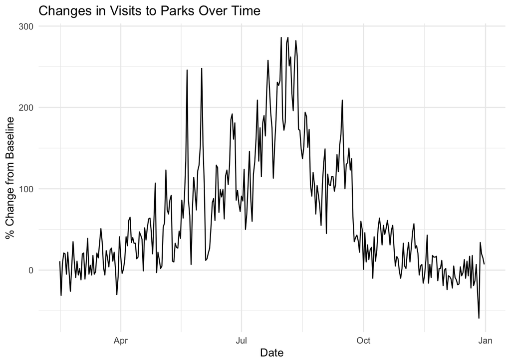

```r
library(ggplot2)

ggplot(data = country, aes(x = date, y = parks)) +
  geom_line(color = "black") +
  labs(title = "Changes in Visits to Parks Over Time",
       x = "Date",
       y = "% Change from Baseline") +
  theme_minimal()
```

### Time-Series Plots with multiple variables

Now, let’s **compare two trends in the same plot**—time spent at **home** (`residential`) vs. at **work** (`workplaces`).

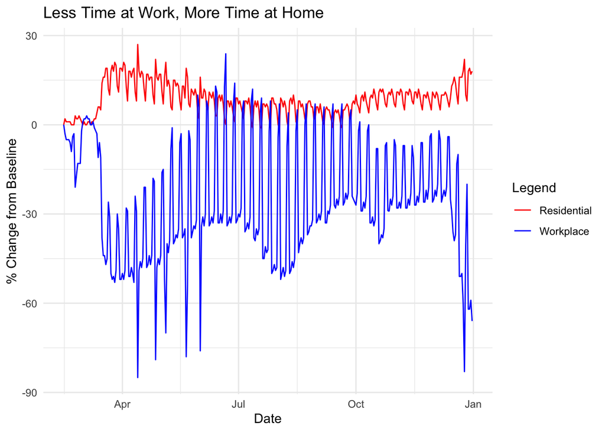

```r
ggplot(data = country) +
  geom_line(aes(x = date, y = residential, color = "Residential")) +
  geom_line(aes(x = date, y = workplaces, color = "Workplace")) +
  scale_color_manual(values = c("Residential" = "red", "Workplace" = "blue")) +
  labs(title = "Less Time at Work, More Time at Home",
       x = "Date",
       y = "% Change from Baseline",
       color = "Legend") +
  theme_minimal()
```

Now, try customizing these plots by changing colors, adding more categories, or adjusting labels! 🚀

### Bar charts

Bar charts are **great for comparing categories** in a dataset. Instead of showing how values change over time (like line charts), bar charts visualize **differences between groups** at a single point in time.

**When to Use a Bar Chart?**

- To compare **values across different categories**
- To show **aggregated statistics** (e.g., averages, sums, or counts)
- To highlight **differences in groups**

A bar chart in `ggplot2` typically follows this structure:

1️⃣ **Define the dataset** → `ggplot(data = your_data)`  
2️⃣ **Set aesthetics (`aes()`)** → `aes(x = category, y = value)`  
3️⃣ **Choose a bar geometry** → `geom_col()` or `geom_bar()`  
4️⃣ **Customize (titles, colors, labels, etc.)**

**Example: Visits to Different Places**

Let's create a bar chart showing the **average mobility change** across different locations using the `country` data set.

```r
library(tidyverse)
library(dplyr)

# Pivot the country dataset to long format
country_long <- country %>%
  pivot_longer(cols = c(retail_and_recreation, grocery_and_pharmacy, parks,
                        transit_stations, workplaces, residential),
               names_to = "place_category",
               values_to = "mobility_change")

# View the transformed data
head(country_long)
```

```
## # A tibble: 6 × 7
##   country_region province city  place_id               date       place_category
##   <chr>          <chr>    <chr> <chr>                  <date>     <chr>
## 1 Netherlands    <NA>     <NA>  ChIJu-SH28MJxkcRnwq9_… 2020-02-15 retail_and_re…
## 2 Netherlands    <NA>     <NA>  ChIJu-SH28MJxkcRnwq9_… 2020-02-15 grocery_and_p…
## 3 Netherlands    <NA>     <NA>  ChIJu-SH28MJxkcRnwq9_… 2020-02-15 parks
## 4 Netherlands    <NA>     <NA>  ChIJu-SH28MJxkcRnwq9_… 2020-02-15 transit_stati…
## 5 Netherlands    <NA>     <NA>  ChIJu-SH28MJxkcRnwq9_… 2020-02-15 workplaces
## 6 Netherlands    <NA>     <NA>  ChIJu-SH28MJxkcRnwq9_… 2020-02-15 residential
## # ℹ 1 more variable: mobility_change <dbl>
```

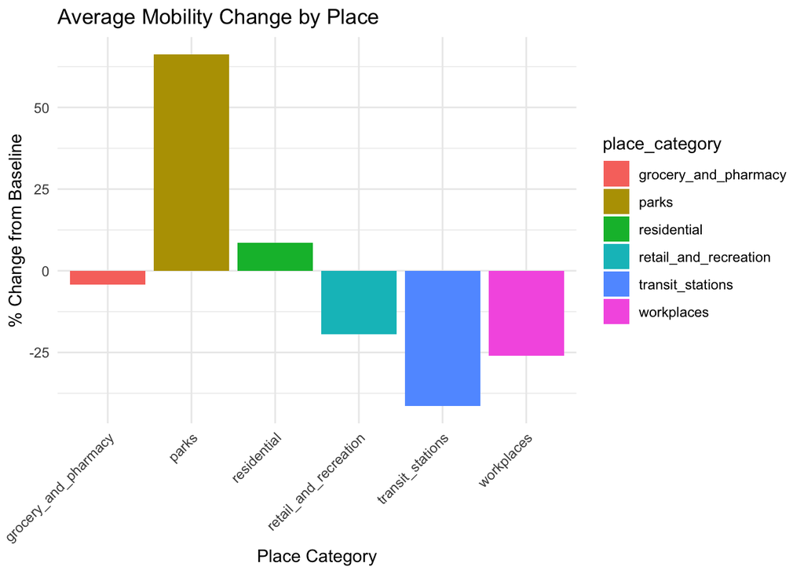

```r
# Aggregate data
country_summary <- country_long %>% group_by(place_category) %>% summarize(avg_mobility_change = mean(mobility_change, na.rm=T))

# Create bar chart
country_summary %>% ggplot(aes(x = place_category, y = avg_mobility_change, fill = place_category)) +
  geom_col() +
  labs(title = "Average Mobility Change by Place",
       x = "Place Category", y = "% Change from Baseline") +
  theme_minimal() +
  theme(axis.text.x = element_text(angle = 45, hjust = 1))  # Rotate labels for readability
```

## Exercise 11: Plotting a time series chart

Please create a time series chart, in which you plot the time spent at **home** (`residential`) vs. at **work** (`workplaces`) for the province of "North Brabant", using the `province` data. Remember to adjust the title of the plot!

As a starting code snippet, please use the code from above.

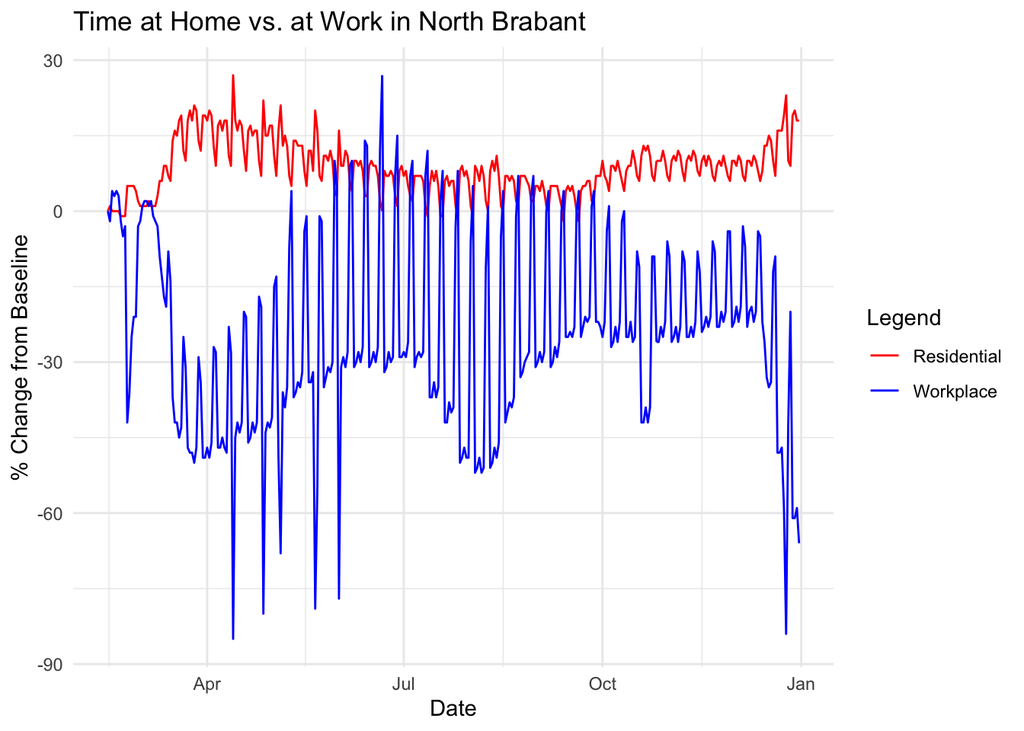

```r
province %>% filter(province == 'North Brabant') %>% ggplot() +
  geom_line(aes(x = date, y = residential, color = "Residential")) +
  geom_line(aes(x = date, y = workplaces, color = "Workplace")) +
  scale_color_manual(values = c("Residential" = "red", "Workplace" = "blue")) +
  labs(title = "Time at Home vs. at Work in North Brabant",
       x = "Date",
       y = "% Change from Baseline",
       color = "Legend") +
  theme_minimal()
```

## Exercise 12: Creating a Bar Chart

In this exercise, we will create a **grouped bar chart** to compare the **average mobility change** for different provinces. Instead of focusing on just one province, we will compare multiple provinces side by side.

To help you get started, we already create the "correct" data set you can use for plotting, called `province_summary`.

```r
# Pivot the province dataset to long format
province_long <- province %>%
  pivot_longer(cols = c(retail_and_recreation, grocery_and_pharmacy, parks,
                        transit_stations, workplaces, residential),
               names_to = "place_category",
               values_to = "mobility_change")
# Aggregate data
province_summary <- province_long %>% group_by(province, place_category) %>% summarize(avg_mobility_change = mean(mobility_change, na.rm=T))
```

Tips:

- Use `ggplot2` with `geom_col()` to compare categories across provinces.
- Use `facet_wrap(~province)` to create separate charts for each province.
- Adjust colors, titles, and labels for clarity.

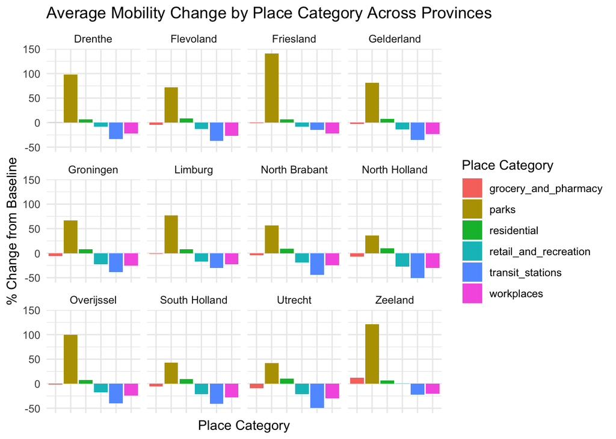

```r
province_summary %>% ggplot(aes(x = place_category, y = avg_mobility_change, fill = place_category)) +
  geom_col(position = "dodge") +
  facet_wrap(~province) +
  labs(title = "Average Mobility Change by Place Category Across Provinces",
       x = "Place Category",
       y = "% Change from Baseline",
       fill = "Place Category") +
  theme_minimal() +
  theme(axis.text.x = element_blank(), axis.ticks.x = element_blank())
```

On a final note: you can conveniently save your plots using the function `ggsave()`, directly after plotting.

```r
ggsave('plot.pdf')
```

This snippet will create `plot.pdf` in your current working directory!

# Conclusion

Congratulations! You've worked through a full **data exploration and visualization** pipeline in R.

**Next Steps?**

- Experiment with **other datasets**—the skills you've learned apply everywhere!
- Try to explore your data set using RMarkdown, and actually render it as a PDF or HTML file
- Keep practicing and tweaking your code—real-world data is rarely perfect, and **exploring, cleaning, and visualizing data is an iterative process!**

Well done, and happy coding! 🎉